# Taller: Medidas de tendencia central y dispersión

Curso de Dinámica Poblacional y Demografía

# 1 Objetivos del taller

Al terminar este taller usted podrá:

1. Calcular en R las principales **medidas de tendencia central** (media, mediana y moda).
2. Calcular las principales **medidas de dispersión** (rango, varianza, desviación estándar, rango intercuartílico y coeficiente de variación).
3. **Interpretar** esos valores en un contexto demográfico real: el crecimiento poblacional.
4. Reconocer **cuándo** conviene cada medida y qué nos dice cada una sobre la población estudiada.

No se necesita saber programar. Todo el código ya está escrito: solo hay que ejecutar cada bloque (botón verde ▶ *Run Current Chunk*) y leer con atención.

# 2 Contexto: ¿por qué medir el crecimiento poblacional?

El **crecimiento poblacional** de un país suele resumirse en su *tasa de crecimiento anual* (en %): cuánto aumenta o disminuye la población en un año. Un país puede crecer al 1.5 % anual, otro puede estar estancado (0 %) y otro puede **decrecer** (tasa negativa) por emigración o baja natalidad.

Cuando tenemos las tasas de **varios** países, una sola cifra no basta. Necesitamos:

- Un valor que resuma el “centro” del grupo → **tendencia central**.
- Un valor que nos diga qué tan **parecidos o dispersos** son esos países entre sí → **dispersión**.

Vamos a trabajar con datos aproximados de crecimiento poblacional de doce países de América Latina.

> **Nota:** los valores son ilustrativos y aproximados, pensados para el ejercicio. En un análisis real usaríamos fuentes como *Our World in Data*, el Banco Mundial o la CEPAL.

# 3 Paso 1: Cargar los datos

En R, un conjunto de valores se guarda en un **vector**, que se crea con la función `c()` (de *combine*). Creamos dos vectores del mismo largo: uno con los nombres de los países y otro con sus tasas.

```r
# Nombres de los países
paises <- c("Colombia", "México", "Argentina", "Chile", "Perú", "Brasil",
            "Ecuador", "Bolivia", "Paraguay", "Uruguay", "Venezuela", "Guatemala")

# Tasa de crecimiento poblacional anual, en % (valores aproximados e ilustrativos)
tasa <- c(1.1, 0.8, 0.5, 0.6, 1.3, 0.5,
          1.4, 1.4, 1.2, 0.3, -1.5, 1.6)

# Miramos los datos juntos en una tabla
data.frame(pais = paises, tasa_crecimiento = tasa)
```

```
#>         pais tasa_crecimiento
#> 1   Colombia              1.1
#> 2     México              0.8
#> 3  Argentina              0.5
#> 4      Chile              0.6
#> 5       Perú              1.3
#> 6     Brasil              0.5
#> 7    Ecuador              1.4
#> 8    Bolivia              1.4
#> 9   Paraguay              1.2
#> 10   Uruguay              0.3
#> 11 Venezuela             -1.5
#> 12 Guatemala              1.6
```

Observe que **Venezuela** tiene una tasa **negativa** (`-1.5`): su población disminuye, en buena parte por la emigración. Guárdelo en mente, porque este “caso raro” (lo que en estadística se llama *valor atípico* o *outlier*) va a influir en algunas medidas.

# 4 Paso 2: Medidas de tendencia central

## 4.1 La media (promedio)

La **media** suma todos los valores y los divide entre el número de casos. Es el “punto de equilibrio” de los datos.

```r
mean(tasa)
```

```
#> [1] 0.7666667
```

**Interpretación:** en promedio, estos doce países crecen alrededor de ese valor por año. Pero cuidado: la media es sensible a los valores extremos. La tasa negativa de Venezuela **jala el promedio hacia abajo**.

## 4.2 La mediana

La **mediana** es el valor que queda justo en el medio cuando ordenamos los datos de menor a mayor. Deja la mitad de los países por debajo y la mitad por encima.

```r
median(tasa)
```

```
#> [1] 0.95
```

**Compare la media y la mediana.** Si son parecidas, los datos son bastante simétricos. Si la media es **menor** que la mediana, es señal de que hay valores bajos (como Venezuela) que la están arrastrando. La mediana es **más robusta**: no se deja afectar tanto por casos raros.

## 4.3 La moda

La **moda** es el valor que más se repite. R base no tiene una función `moda()`, pero podemos encontrarla mirando la tabla de frecuencias.

En tasas de crecimiento (números con decimales) casi ningún valor se repite, así que la moda no es muy útil aquí. La moda brilla con **datos discretos**. Usemos otro ejemplo demográfico: el **número de hijos** reportado por 15 mujeres en una pequeña encuesta.

```r
# Número de hijos por mujer en una encuesta hipotética
hijos <- c(2, 1, 3, 2, 0, 2, 4, 2, 1, 3, 2, 2, 0, 1, 2)

# Tabla de frecuencias: cuántas veces aparece cada valor
table(hijos)
```

```
#> hijos
#> 0 1 2 3 4
#> 2 3 7 2 1
```

```r
# La moda es el valor con mayor frecuencia
frecuencias <- table(hijos)
names(frecuencias)[which.max(frecuencias)]
```

```
#> [1] "2"
```

**Interpretación:** el valor más frecuente indica el tamaño de familia “típico” en la muestra. Para variables como número de hijos, estado civil o nivel educativo, la moda suele ser la medida de tendencia central más informativa.

> **Idea clave:** no existe una “mejor” medida de tendencia central. La media aprovecha toda la información pero se deja afectar por atípicos; la mediana resiste los atípicos; la moda es ideal para datos discretos o categóricos.

# 5 Paso 3: Medidas de dispersión

Las medidas de tendencia central nos dan el “centro”, pero no nos dicen si los países se parecen entre sí o no. Para eso están las **medidas de dispersión**.

## 5.1 Rango (mínimo, máximo y su diferencia)

```r
min(tasa)          # valor más bajo
```

```
#> [1] -1.5
```

```r
max(tasa)          # valor más alto
```

```
#> [1] 1.6
```

```r
max(tasa) - min(tasa)   # el rango: distancia entre el mayor y el menor
```

```
#> [1] 3.1
```

**Interpretación:** el rango nos dice qué tan separados están los casos extremos. Es fácil de entender, pero depende **solo** de dos valores, así que un único atípico (Venezuela) lo puede inflar mucho.

## 5.2 Varianza y desviación estándar

La **varianza** mide, en promedio, qué tan lejos está cada país de la media (elevando al cuadrado esas distancias). La **desviación estándar** es la raíz cuadrada de la varianza, y tiene la ventaja de estar en las **mismas unidades** que los datos (en %).

```r
var(tasa)   # varianza
```

```
#> [1] 0.6915152
```

```r
sd(tasa)    # desviación estándar (en puntos porcentuales)
```

```
#> [1] 0.8315739
```

**Interpretación:** la desviación estándar responde a “en promedio, ¿cuánto se aleja cada país del crecimiento promedio?”. Una desviación **pequeña** significa que los países crecen a ritmos parecidos; una **grande**, que hay mucha heterogeneidad demográfica en la región.

## 5.3 Cuartiles y rango intercuartílico (IQR)

Los **cuartiles** dividen los datos ordenados en cuatro partes iguales. El **rango intercuartílico (IQR)** es la distancia entre el tercer cuartil (75 %) y el primero (25 %): abarca el 50 % central de los países e **ignora los extremos**, por lo que resiste bien a los atípicos.

```r
quantile(tasa)   # mínimo, Q1, mediana, Q3, máximo
```

```
#>     0%    25%    50%    75%   100%
#> -1.500  0.500  0.950  1.325  1.600
```

```r
IQR(tasa)        # rango intercuartílico (Q3 - Q1)
```

```
#> [1] 0.825
```

## 5.4 Coeficiente de variación (CV)

¿Qué pasa si queremos comparar la dispersión de dos variables medidas en **escalas distintas**, como la tasa de crecimiento (en %) y el tamaño de la población (en millones)? La desviación estándar no sirve para compararlas directamente, porque están en unidades diferentes.

El **coeficiente de variación** resuelve esto: expresa la desviación estándar **como porcentaje de la media**, así que no tiene unidades y permite comparar.

```r
# Población total aproximada, en millones (mismo orden que 'paises')
poblacion <- c(52, 129, 46, 20, 34, 216, 18, 12, 7, 3.5, 28, 18)

# Coeficiente de variación = (desviación estándar / media) * 100
cv_tasa      <- (sd(tasa) / mean(tasa)) * 100
cv_poblacion <- (sd(poblacion) / mean(poblacion)) * 100

cv_tasa
```

```
#> [1] 108.4662
```

```r
cv_poblacion
```

```
#> [1] 128.488
```

**Interpretación:** aunque la población tiene una desviación estándar enorme *en millones* y la tasa una muy pequeña *en %*, el CV las pone en el mismo lenguaje. El CV más alto indica la variable **relativamente más dispersa**. Compárelos: ¿en qué son más heterogéneos estos países, en su ritmo de crecimiento o en su tamaño?

# 6 Paso 4: Un resumen de todo con una sola función

La función `summary()` entrega de un golpe el mínimo, los cuartiles, la mediana y la media.

```r
summary(tasa)
```

```
#>    Min. 1st Qu.  Median    Mean 3rd Qu.    Max.
#> -1.5000  0.5000  0.9500  0.7667  1.3250  1.6000
```

Y podemos armar una pequeña tabla propia con las medidas principales:

```r
resumen <- data.frame(
  Medida = c("Media", "Mediana", "Desv. estándar", "IQR", "Coef. variación (%)"),
  Valor  = round(c(mean(tasa), median(tasa), sd(tasa), IQR(tasa),
                   (sd(tasa)/mean(tasa))*100), 2)
)
resumen
```

```
#>                Medida  Valor
#> 1               Media   0.77
#> 2             Mediana   0.95
#> 3      Desv. estándar   0.83
#> 4                 IQR   0.83
#> 5 Coef. variación (%) 108.47
```

# 7 Paso 5: Visualizar la dispersión

Un **histograma** muestra cómo se reparten las tasas, y un **diagrama de caja (boxplot)** resume visualmente la mediana, los cuartiles y los posibles atípicos.

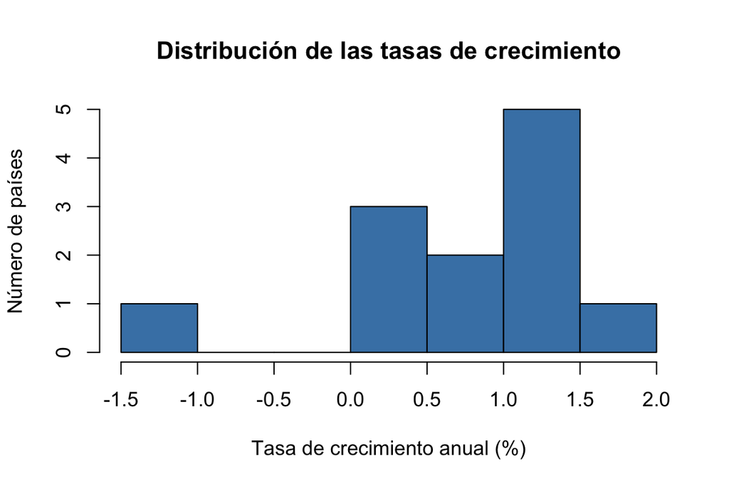

```r
hist(tasa,
     main = "Distribución de las tasas de crecimiento",
     xlab = "Tasa de crecimiento anual (%)",
     ylab = "Número de países",
     col = "steelblue")
```

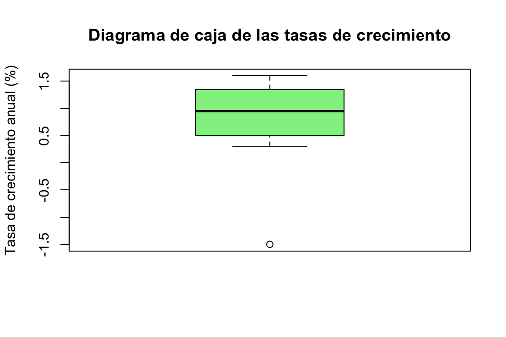

```r
boxplot(tasa,
        main = "Diagrama de caja de las tasas de crecimiento",
        ylab = "Tasa de crecimiento anual (%)",
        col = "lightgreen")
```

**Interpretación:** en el boxplot, la línea gruesa es la **mediana**; la caja abarca el **50 % central** (el IQR); y cualquier punto muy separado se marca como posible **atípico**. ¿Aparece Venezuela como un punto por fuera?

# 8 Ejercicios para resolver

Trabaje directamente en este documento, escribiendo el código en los bloques vacíos.

**Ejercicio 1.** Estas son tasas de crecimiento anual aproximadas (%) de varios departamentos de Colombia. Cárguelas en un vector llamado `tasa_dpto` y calcule su **media** y **mediana**. ¿Cuál es mayor? ¿Qué le sugiere eso sobre la forma de los datos?

```r
# Amazonas, Antioquia, Atlántico, Bogotá, Chocó, Guaviare, Nariño, Valle
tasa_dpto <- c(1.8, 0.9, 1.1, 0.4, 1.5, 2.0, 0.7, 0.6)

# Escriba aquí su código:
```

**Ejercicio 2.** Calcule para `tasa_dpto` la **desviación estándar** y el **rango intercuartílico**. En una frase, explique qué le dice cada uno sobre la heterogeneidad entre departamentos.

```r
# Escriba aquí su código:
```

**Ejercicio 3.** Calcule el **coeficiente de variación** de `tasa_dpto` y compárelo con el de los países (`cv_tasa`). ¿Los departamentos de Colombia son más homogéneos o más heterogéneos entre sí que los países de la región?

```r
# Escriba aquí su código:
```

**Ejercicio 4 (interpretación, sin código).** Suponga que un/a colega dice: *“En promedio los países crecen, así que la población de la región está aumentando en todas partes”*. Con base en lo que calculó (media, mediana, dispersión y el caso de Venezuela), escriba dos o tres líneas explicando por qué esa afirmación es incompleta.

*Su respuesta:*

# 9 Reto opcional

Cree su propia función `moda()` que reciba un vector y devuelva el valor (o los valores) más frecuente(s), y pruébela con el vector `hijos`. Pista: combine `table()`, `max()` y `which()`.

```r
# Escriba aquí su código:
```

# 10 Síntesis

| Pregunta | Medida adecuada |
| --- | --- |
| ¿Cuál es el valor “central” o típico? | Media, mediana, moda |
| ¿Qué tan lejos llegan los extremos? | Rango (mín, máx) |
| ¿Cuánto se alejan los datos del promedio? | Varianza y desviación estándar |
| ¿Cómo es el 50 % central, sin atípicos? | Cuartiles e IQR |
| ¿Cómo comparo la dispersión de variables en escalas distintas? | Coeficiente de variación |

La lección demográfica de fondo: **un solo número nunca describe a una población**. El crecimiento poblacional se entiende mejor mirando a la vez su centro y su dispersión, y prestando atención a los casos que se salen del patrón.